# Part_iv_interpretation_A

Yijun Zhou

4/26/2022

### load library

```r
library(tidyverse)
library(knitr)
library(caret)
library(reshape2)
df_all <- readr::read_csv("final_project_train.csv", col_names = TRUE)
df_all <-df_all%>%glimpse
```

```
## Rows: 677
## Columns: 38
## $ rowid    <dbl> 1, 3, 4, 5, 8, 9, 11, 14, 15, 16, 17, 18, 19, 22, 24, 25, 27,…
## $ region   <chr> "XX", "XX", "XX", "XX", "XX", "XX", "XX", "XX", "XX", "XX", "…
## $ customer <chr> "B", "B", "B", "B", "B", "B", "B", "B", "B", "B", "B", "B", "…
## $ xb_01    <dbl> 4.000000, 1.000000, 2.000000, 2.520000, 2.548387, 3.071429, 3…
## $ xb_02    <dbl> 4, 1, 2, 11, 6, 6, 10, 12, 9, 10, 8, 10, 10, 8, 6, 10, 13, 10…
## $ xb_03    <dbl> 4, 1, 2, -6, -1, 1, -4, -4, -2, -4, -2, -2, -2, -4, 1, -4, -3…
## $ xn_01    <dbl> 3.0000000, 2.0000000, 2.0000000, 1.5333333, 0.8387097, 1.8571…
## $ xn_02    <dbl> 3, 2, 4, 9, 3, 8, 6, 10, 10, 4, 6, 8, 9, 5, 7, 12, 12, 6, 6, …
## $ xn_03    <dbl> 3, 2, 0, -3, -4, -2, -5, -6, -3, -5, -3, -6, -4, -3, 0, -5, -…
## $ xa_01    <dbl> 12.000000, 3.000000, 9.000000, 7.080000, 6.451613, 6.857143, …
## $ xa_02    <dbl> 12, 3, 9, 29, 17, 18, 24, 27, 20, 19, 15, 24, 24, 15, 14, 26,…
## $ xa_03    <dbl> 12, 3, 9, -7, -2, 2, -9, -5, -3, -3, -1, 1, -2, -3, 3, -4, -5…
## $ xb_04    <dbl> 1.3333333, 1.0000000, 1.0000000, 0.8950476, 1.2247312, 1.1857…
```

[output cut: 25 more lines]

# overview of A

• With the model training completed, you can now answer meaningful questions associated with the data!  
• You must identify the best regression model and the best classification model.  
• Identify the most important variables associated with your best performing models.  
• Are the most important variables similar for the regression and classification tasks?  
• Does one of the sentiment derived feature types “dominate” the most important variables?  
• Does one of the sentiment derived feature types appear to be not helpful at all?  
• Based on your modeling results, do you feel these sentiment derived features are helpful at predicting the outputs?  
• Essentially, do you feel the model results are “good” and was I right about the relationship between report sentiment and the outputs?

## Identify the best regression model and the best classification model.

```r
fit_lm_all_inputs<-readr::read_rds("fit_lm_all_inputs.rds")
fit_lm_all_pairwise<-readr::read_rds("fit_lm_all_pairwise.rds")
fit_lm_3<-readr::read_rds("fit_lm_3.rds")
fit_lm_8<-readr::read_rds("fit_lm_8.rds")
fit_glmnet_pairwise_tune<-readr::read_rds("fit_glmnet_pairwise_tune.rds")
fit_glmnet_3_tune<-readr::read_rds("fit_glmnet_3_tune.rds")
fit_glmnet_8_tune<-readr::read_rds("fit_glmnet_8_tune.rds")
fit_nnet_additive_tune<-readr::read_rds("fit_nnet_additive_tune.rds")
fit_rf_additive_tune<-readr::read_rds("fit_rf_additive_tune.rds")
fit_xgb_additive_tune<-readr::read_rds("fit_xgb_additive_tune.rds")
fit_svm_additive_tune<-readr::read_rds("fit_svm_additive_tune.rds")
fit_pls_additive_tune<-readr::read_rds("fit_pls_additive_tune.rds")
```

```r
c_fit_glm_all_inputs<-readr::read_rds("c_fit_glm_all_inputs.rds")
c_fit_glm_all_pairwise<-readr::read_rds("c_fit_glm_all_pairwise.rds")
c_fit_glm_8<-readr::read_rds("c_fit_glm_8.rds")
c_fit_glm_2<-readr::read_rds("c_fit_glm_2.rds")
c_fit_glmnet_pairwise_tune<-readr::read_rds("c_fit_glmnet_pairwise_tune.rds")
c_fit_glmnet_3_tune<-readr::read_rds("c_fit_glmnet_3_tune.rds")
c_fit_glmnet_2_tune<-readr::read_rds("c_fit_glmnet_2_tune.rds")
c_fit_nnet_additive_tune<-readr::read_rds("c_fit_nnet_additive_tune.rds")
c_fit_rf_additive_tune<-readr::read_rds("c_fit_rf_additive_tune.rds")
c_fit_xgb_additive_tune<-readr::read_rds("c_fit_xgb_additive_tune.rds")
c_fit_svm_additive_tune<-readr::read_rds("c_fit_svm_additive_tune.rds")
c_fit_adaboost_additive_tune<-readr::read_rds("c_fit_adaboost_additive_tune.rds")
c_pca_nnet_additive_tune<-readr::read_rds("c_pca_nnet_additive_tune.rds")
```

Based on the results of Part_iiD, the best regression model is mod_9-“fit_rf_additive_tune”, which is the random forest model with “PCA” as preProcessing method, and mod_10 -“fit_xgb_additive_tune”, which is the xgboost model with “PCA” as preProcessing method.

Based on the results of Part_iii_D, the best classification model is mod13-“c_pca_nnet_additive_tune”, which is a neural network model with “PCA” as the preProcessing method.

## Identify the most important variables associated with your best performing models.

The best regression model is random forest model, based on the results below, the top4 most important variables are {xw01,region,xw03,xn01}

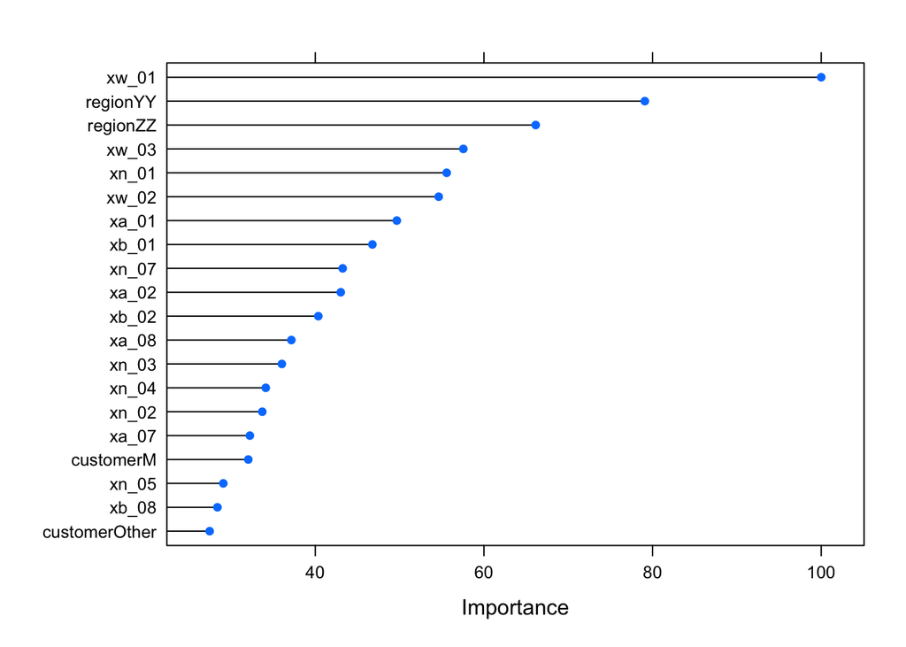

```r
varImp(fit_rf_additive_tune)%>%plot(top=20)
```

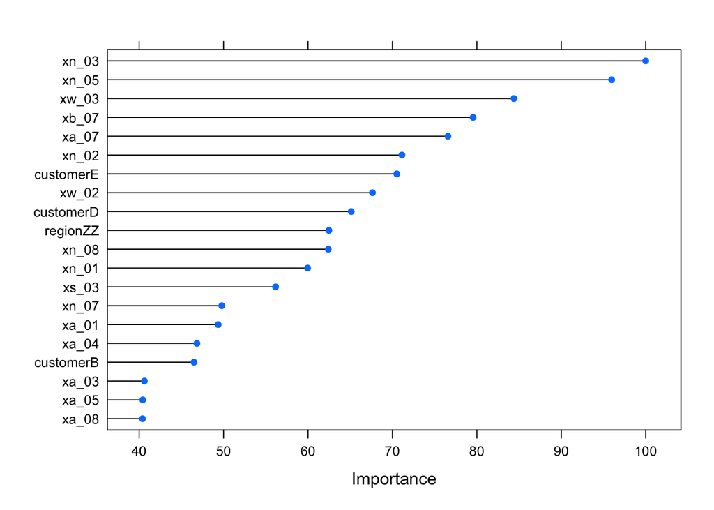

```r
varImp(c_fit_glmnet_2_tune)%>%plot(top=20)
```

## Does one of the sentiment derived feature types “dominate” the most important variables?

Based on the parts before, the variables begin with “xw_” and “xn_” dominate most, especially {xw_03,xw_01,xn_01}.  
Based on the data description, the variables begin with “xw_” is word count derived features. the number of word count is large means that the customer prefers to spend a lot of time on the product.

## Based on your modeling results, do you feel these sentiment derived features are helpful at predicting the outputs? Essentially, do you feel the model results are “good” and was I right about the relationship between report sentiment and the outputs?

Based on my results, I think most of the sentiment derived features are helpful at predicting the outputs, especially those begin with “xw_” and “xn_”, even though some have nothing to do with the result.  
Therefore, since the accuracy of classification is above 0.82 for most of the classification models, and the rmse of regression models is very low, I think we can consider the model results are “good” enough. However, since the data is close to imbalanced,( the probability of event is only 18%, while the data will be considered imbalanced when the probability is above 15%), I think if I have more time to do some processing to reduce the condition of imbalancing, the model can be better and the result can be better.

# overview of Part_iv_Interpretation_ivB

```r
df_all <- readr::read_csv("final_project_train.csv", col_names = TRUE)
df_all <-df_all%>%glimpse
```

```
## Rows: 677
## Columns: 38
## $ rowid    <dbl> 1, 3, 4, 5, 8, 9, 11, 14, 15, 16, 17, 18, 19, 22, 24, 25, 27,…
## $ region   <chr> "XX", "XX", "XX", "XX", "XX", "XX", "XX", "XX", "XX", "XX", "…
## $ customer <chr> "B", "B", "B", "B", "B", "B", "B", "B", "B", "B", "B", "B", "…
## $ xb_01    <dbl> 4.000000, 1.000000, 2.000000, 2.520000, 2.548387, 3.071429, 3…
## $ xb_02    <dbl> 4, 1, 2, 11, 6, 6, 10, 12, 9, 10, 8, 10, 10, 8, 6, 10, 13, 10…
## $ xb_03    <dbl> 4, 1, 2, -6, -1, 1, -4, -4, -2, -4, -2, -2, -2, -4, 1, -4, -3…
## $ xn_01    <dbl> 3.0000000, 2.0000000, 2.0000000, 1.5333333, 0.8387097, 1.8571…
## $ xn_02    <dbl> 3, 2, 4, 9, 3, 8, 6, 10, 10, 4, 6, 8, 9, 5, 7, 12, 12, 6, 6, …
## $ xn_03    <dbl> 3, 2, 0, -3, -4, -2, -5, -6, -3, -5, -3, -6, -4, -3, 0, -5, -…
## $ xa_01    <dbl> 12.000000, 3.000000, 9.000000, 7.080000, 6.451613, 6.857143, …
## $ xa_02    <dbl> 12, 3, 9, 29, 17, 18, 24, 27, 20, 19, 15, 24, 24, 15, 14, 26,…
## $ xa_03    <dbl> 12, 3, 9, -7, -2, 2, -9, -5, -3, -3, -1, 1, -2, -3, 3, -4, -5…
## $ xb_04    <dbl> 1.3333333, 1.0000000, 1.0000000, 0.8950476, 1.2247312, 1.1857…
```

[output cut: 25 more lines]

```r
df_all<-df_all%>%split(.$customer)
```

```r
df_A<-df_all$A%>%mutate(log_response=log(response))%>%select(-rowid,-outcome,-response)
df_B<-df_all$B%>%mutate(log_response=log(response))%>%select(-rowid,-outcome,-response)
df_D<-df_all$D%>%mutate(log_response=log(response))%>%select(-rowid,-outcome,-response)
df_E<-df_all$E%>%mutate(log_response=log(response))%>%select(-rowid,-outcome,-response)
df_G<-df_all$G%>%mutate(log_response=log(response))%>%select(-rowid,-outcome,-response)
df_K<-df_all$K%>%mutate(log_response=log(response))%>%select(-rowid,-outcome,-response)
df_M<-df_all$M%>%mutate(log_response=log(response))%>%select(-rowid,-outcome,-response)
df_other<-df_all$Other%>%
  mutate(log_response=log(response))%>%select(-rowid,-outcome,-response)
df_Q<-df_all$Q%>%mutate(log_response=log(response))%>%select(-rowid,-outcome,-response)
```

```r
result_A<-predict(fit_rf_additive_tune,df_A)
result_B<-predict(fit_rf_additive_tune,df_B)
result_D<-predict(fit_rf_additive_tune,df_D)
result_E<-predict(fit_rf_additive_tune,df_E)
result_G<-predict(fit_rf_additive_tune,df_G)
result_K<-predict(fit_rf_additive_tune,df_K)
result_M<-predict(fit_rf_additive_tune,df_M)
result_other<-predict(fit_rf_additive_tune,df_other)
result_Q<-predict(fit_rf_additive_tune,df_Q)
results_RMSE<-c(A=RMSE(df_A$log_response,result_A),
                B=RMSE(df_B$log_response,result_B),
                D=RMSE(df_D$log_response,result_D),
                E=RMSE(df_E$log_response,result_E),
                G=RMSE(df_G$log_response,result_G),
                K=RMSE(df_K$log_response,result_K),
                M=RMSE(df_M$log_response,result_M),
                Other=RMSE(df_other$log_response,result_other),
                Q=RMSE(df_other$log_response,result_Q))
```

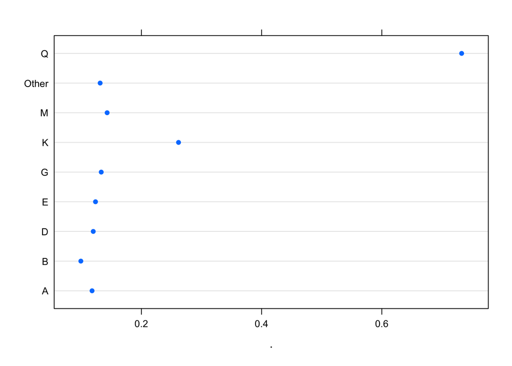

```r
results_RMSE%>%dotplot()
```

```r
df_all <- readr::read_csv("final_project_train.csv", col_names = TRUE)
df_all<-df_all%>%split(.$customer)
df_A<-df_all$A%>%select(-rowid,-response)
df_B<-df_all$B%>%select(-rowid,-response)
df_D<-df_all$D%>%select(-rowid,-response)
df_E<-df_all$E%>%select(-rowid,-response)
df_G<-df_all$G%>%select(-rowid,-response)
df_K<-df_all$K%>%select(-rowid,-response)
df_M<-df_all$M%>%select(-rowid,-response)
df_other<-df_all$Other%>%select(-rowid,-response)
df_Q<-df_all$Q%>%select(-rowid,-response)
```

```r
result_A<-predict(c_pca_nnet_additive_tune,df_A)
result_B<-predict(c_pca_nnet_additive_tune,df_A)
result_D<-predict(c_pca_nnet_additive_tune,df_A)
result_E<-predict(c_pca_nnet_additive_tune,df_A)
result_G<-predict(c_pca_nnet_additive_tune,df_A)
result_K<-predict(c_pca_nnet_additive_tune,df_A)
result_M<-predict(c_pca_nnet_additive_tune,df_A)
result_other<-predict(c_pca_nnet_additive_tune,df_A)
result_Q<-predict(c_pca_nnet_additive_tune,df_A)
results_acc<-c(A=sum(ifelse(result_A==df_A$outcome,1,0))/length(result_A),
               B=sum(ifelse(result_B==df_B$outcome,1,0))/length(result_B),
               D=sum(ifelse(result_D==df_D$outcome,1,0))/length(result_D),
               E=sum(ifelse(result_E==df_E$outcome,1,0))/length(result_E),
               G=sum(ifelse(result_G==df_G$outcome,1,0))/length(result_G),
               K=sum(ifelse(result_K==df_K$outcome,1,0))/length(result_K),
               M=sum(ifelse(result_M==df_M$outcome,1,0))/length(result_M),
               other=sum(ifelse(result_other==df_other$outcome,1,0))/length(result_other),
               Q=sum(ifelse(result_Q==df_Q$outcome,1,0))/length(result_Q))
```

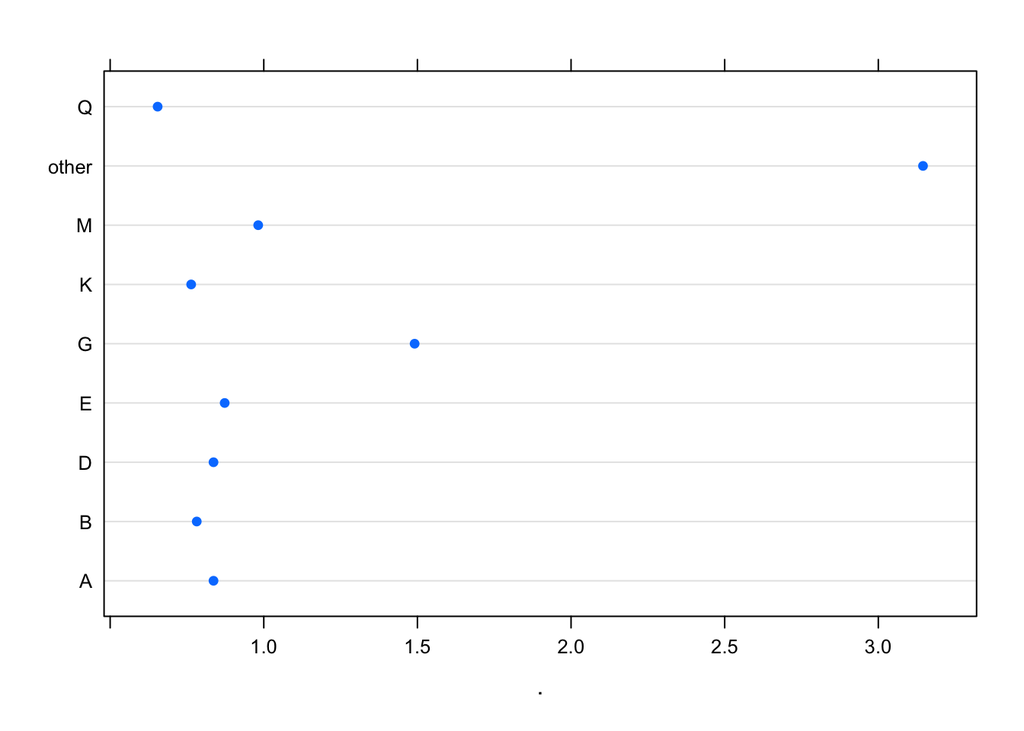

```r
results_acc%>%dotplot()
```

To make the result more precious, I prefer to choose some data from the whole data set and do it again.

```r
set.seed(1235)
df_all <- readr::read_csv("final_project_train.csv", col_names = TRUE)
test_id<-sample(1:nrow(df_all),size=floor(0.1*nrow(df_all)))
df_all<-df_all %>%slice(test_id)
```

```r
df_all<-df_all%>%split(.$customer)
```

```r
df_A<-df_all$A%>%mutate(log_response=log(response))%>%select(-rowid,-outcome,-response)
df_B<-df_all$B%>%mutate(log_response=log(response))%>%select(-rowid,-outcome,-response)
df_D<-df_all$D%>%mutate(log_response=log(response))%>%select(-rowid,-outcome,-response)
df_E<-df_all$E%>%mutate(log_response=log(response))%>%select(-rowid,-outcome,-response)
df_G<-df_all$G%>%mutate(log_response=log(response))%>%select(-rowid,-outcome,-response)
df_K<-df_all$K%>%mutate(log_response=log(response))%>%select(-rowid,-outcome,-response)
df_M<-df_all$M%>%mutate(log_response=log(response))%>%select(-rowid,-outcome,-response)
df_other<-df_all$Other%>%
  mutate(log_response=log(response))%>%select(-rowid,-outcome,-response)
df_Q<-df_all$Q%>%mutate(log_response=log(response))%>%select(-rowid,-outcome,-response)
```

```r
result_A<-predict(fit_svm_additive_tune,df_A)
result_B<-predict(fit_svm_additive_tune,df_B)
result_D<-predict(fit_svm_additive_tune,df_D)
result_E<-predict(fit_svm_additive_tune,df_E)
result_G<-predict(fit_svm_additive_tune,df_G)
result_K<-predict(fit_svm_additive_tune,df_K)
result_M<-predict(fit_svm_additive_tune,df_M)
result_other<-predict(fit_svm_additive_tune,df_other)
result_Q<-predict(fit_svm_additive_tune,df_Q)
results_RMSE<-c(A=RMSE(df_A$log_response,result_A),
                B=RMSE(df_B$log_response,result_B),
                D=RMSE(df_D$log_response,result_D),
                E=RMSE(df_E$log_response,result_E),
                G=RMSE(df_G$log_response,result_G),
                K=RMSE(df_K$log_response,result_K),
                M=RMSE(df_M$log_response,result_M),
                Other=RMSE(df_other$log_response,result_other),
                Q=RMSE(df_other$log_response,result_Q))
```

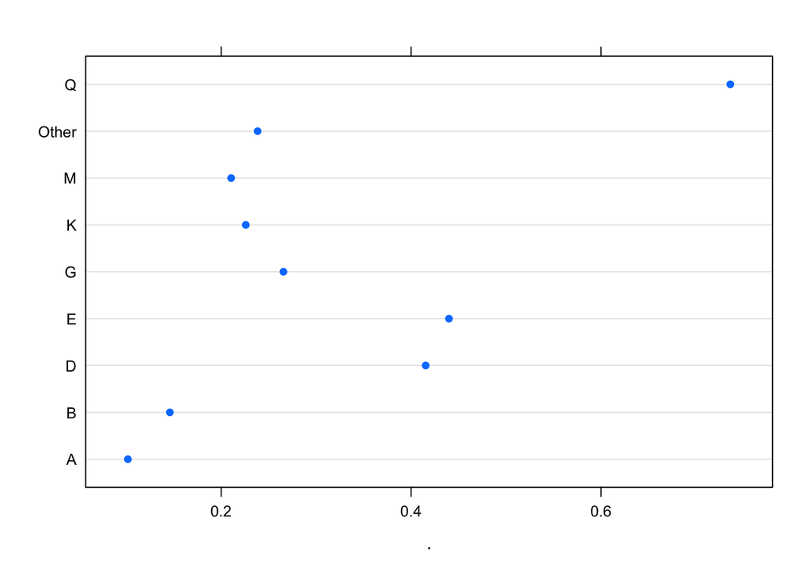

```r
results_RMSE%>%dotplot()
```

```r
df_all <- readr::read_csv("final_project_train.csv", col_names = TRUE)
test_id<-sample(1:nrow(df_all),size=floor(0.1*nrow(df_all)))
df_all<-df_all %>%slice(test_id)
df_all<-df_all%>%split(.$customer)
df_A<-df_all$A%>%select(-rowid,-response)
df_B<-df_all$B%>%select(-rowid,-response)
df_D<-df_all$D%>%select(-rowid,-response)
df_E<-df_all$E%>%select(-rowid,-response)
df_G<-df_all$G%>%select(-rowid,-response)
df_K<-df_all$K%>%select(-rowid,-response)
df_M<-df_all$M%>%select(-rowid,-response)
df_other<-df_all$Other%>%select(-rowid,-response)
df_Q<-df_all$Q%>%select(-rowid,-response)
```

```r
result_A<-predict(c_fit_glmnet_2_tune,df_A)
result_B<-predict(c_fit_glmnet_2_tune,df_A)
result_D<-predict(c_fit_glmnet_2_tune,df_A)
result_E<-predict(c_fit_glmnet_2_tune,df_A)
result_G<-predict(c_fit_glmnet_2_tune,df_A)
result_K<-predict(c_fit_glmnet_2_tune,df_A)
result_M<-predict(c_fit_glmnet_2_tune,df_A)
result_other<-predict(c_fit_glmnet_2_tune,df_A)
result_Q<-predict(c_fit_glmnet_2_tune,df_A)
results_acc<-c(A=sum(ifelse(result_A==df_A$outcome,1,0))/length(result_A),
               B=sum(ifelse(result_B==df_B$outcome,1,0))/length(result_B),
               D=sum(ifelse(result_D==df_D$outcome,1,0))/length(result_D),
               E=sum(ifelse(result_E==df_E$outcome,1,0))/length(result_E),
               G=sum(ifelse(result_G==df_G$outcome,1,0))/length(result_G),
               K=sum(ifelse(result_K==df_K$outcome,1,0))/length(result_K),
               M=sum(ifelse(result_M==df_M$outcome,1,0))/length(result_M),
               other=sum(ifelse(result_other==df_other$outcome,1,0))/length(result_other),
               Q=sum(ifelse(result_Q==df_Q$outcome,1,0))/length(result_Q))
```

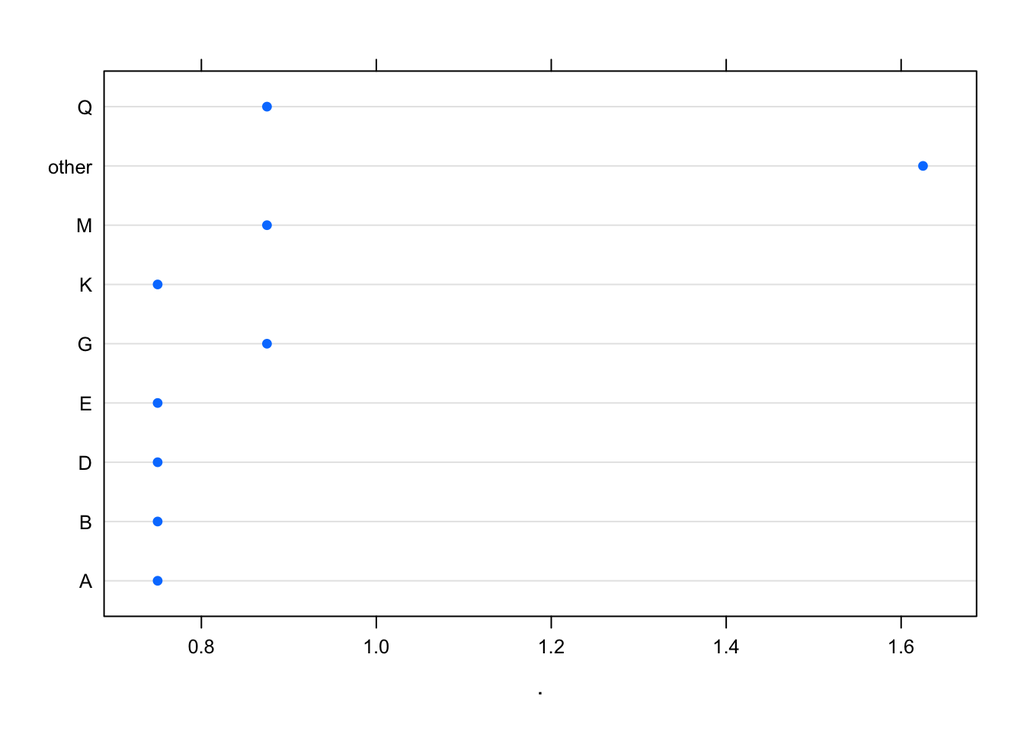

```r
results_acc %>%dotplot()
```

# overview_Part_iv_Interpretation_C

• You must visualize the trends associated with the hardest to predict customer with respect to the most important sentiment derived feature.  
• You are free to select whether you wish to visualize the regression model trends (log- transformed response) or the classification model trends (event probability).  
• Predictions should be made using the best performing model.  
• You must visualize your predictive trends using the following style:  
The primary input should be used as the x-aesthetic in a graphic.  
The secondary input should be used as a facet variable – it is recommended to use 4 to 6 unique values if your secondary input is a continuous variable  
You must decide what values to use for the remaining inputs  
• What conclusions can you draw from the predictive trends?

Based on the analysis above, the hardest to predict customer is Q.

I prefer to use the RF regression model.

```r
tidy_predict <- function(mod, xnew)
{
  pred_df <- predict(mod, xnew, interval = "confidence") %>%
    as.data.frame() %>% tibble::as_tibble() %>%
    select(pred = fit, ci_lwr = lwr, ci_upr = upr) %>%
    bind_cols(predict(mod, xnew, interval = 'prediction') %>%
                as.data.frame() %>% tibble::as_tibble() %>%
                select(pred_lwr = lwr, pred_upr = upr))
  xnew %>% bind_cols(pred_df)
}
```

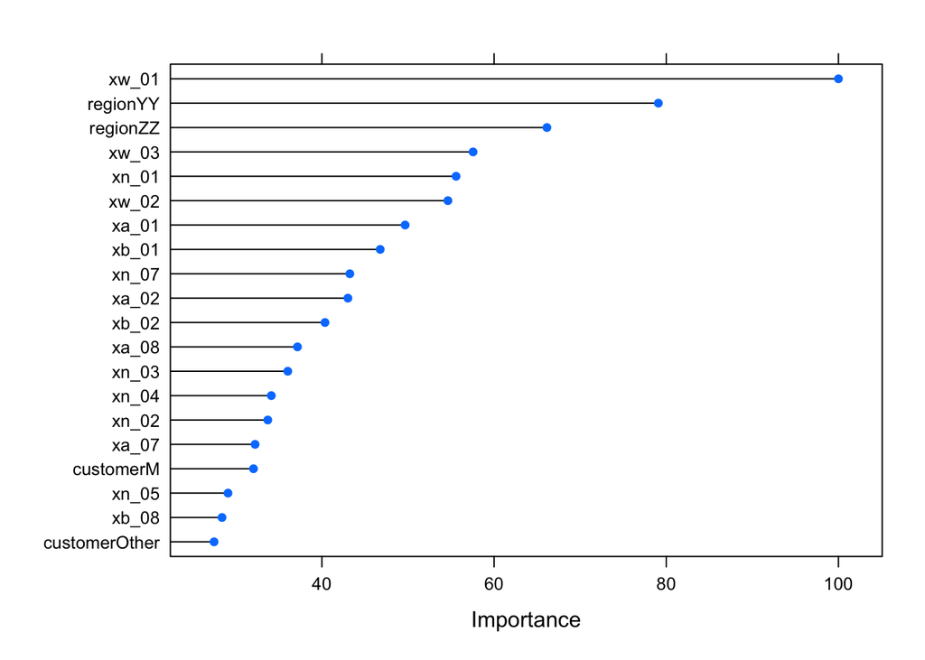

```r
varImp(fit_rf_additive_tune)%>%plot(top=20)
```

Based on the figure above , we can know that {xw_01} is the best inputs.  
Based on the exploration of part i, xw_01 is gaussian distribution with $\miu=60$ and $\sigma=30$, and set the number of points is 101. Besides, the second important input is {region},which includes “xx,yy,zz”.

```r
viz_grid<- expand.grid(#xw_01 =seq(30,90,length.out=101) ,
                        xw_01=seq(30,90,length.out=101),
                        customer=c('Q'),
                        region=c('XX','YY','ZZ'),
                        xw_03=c(0),
                        xb_01=c(0),xb_02=c(0),xb_03=c(0),xb_04=c(0),
                        xb_05=c(0),xb_06=c(0),xb_07=c(0),xb_08=c(0),
                        xn_01=c(0),xn_02=c(0),xn_03=c(0),xn_04=c(0),
                        xn_05=c(0),xn_06=c(0),xn_07=c(0),xn_08=c(0),
                        xa_01=c(0),xa_02=c(0),xa_03=c(0),xa_04=c(0),
                        xa_05=c(0),xa_06=c(0),xa_07=c(0),xa_08=c(0),
                        xw_02=c(0),
                        xs_01=c(0),xs_02=c(0),xs_03=c(0),xs_04=c(0),xs_05=c(0),xs_06=c(0),
                        KEEP.OUT.ATTRS = FALSE,
                        stringsAsFactors = FALSE) %>%
  as.data.frame() %>% tibble::as_tibble()
```

[output not shown]

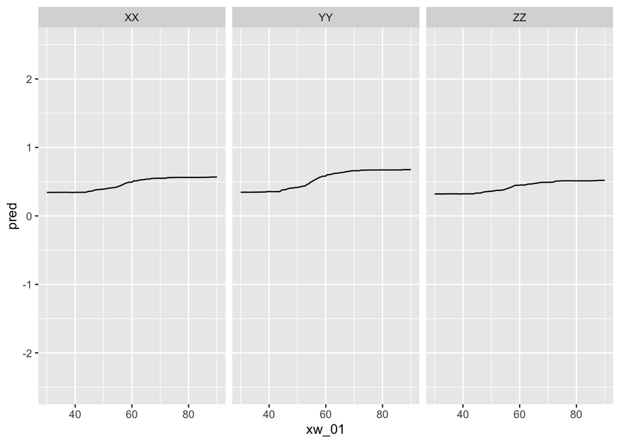

```r
pred<-predict(fit_rf_additive_tune,viz_grid)
viz_grid %>%
  bind_cols(pred) %>%
  ggplot(mapping=aes(x=xw_01)) +
  geom_line(mapping=aes(y=pred))+
  facet_grid(~region)+
  coord_cartesian(ylim=c(-2.5,2.5))
```

```r
viz_grid<- expand.grid(#xw_01 =seq(30,90,length.out=101) ,
                        xw_03=seq(30,150,length.out=101),
                        customer=c('Q'),
                        region=c('XX','YY','ZZ'),
                        xw_01=seq(90,110,length.out=3),
                        xb_01=c(0),xb_02=c(0),xb_03=c(0),xb_04=c(0),
                        xb_05=c(0),xb_06=c(0),xb_07=c(0),xb_08=c(0),
                        xn_01=c(0),xn_02=c(0),xn_03=c(0),xn_04=c(0),
                        xn_05=c(0),xn_06=c(0),xn_07=c(0),xn_08=c(0),
                        xa_01=c(0),xa_02=c(0),xa_03=c(0),xa_04=c(0),
                        xa_05=c(0),xa_06=c(0),xa_07=c(0),xa_08=c(0),
                        xw_02=c(0),
                        xs_01=c(0),xs_02=c(0),xs_03=c(0),xs_04=c(0),xs_05=c(0),xs_06=c(0),
                        KEEP.OUT.ATTRS = FALSE,
                        stringsAsFactors = FALSE) %>%
  as.data.frame() %>% tibble::as_tibble()
```

[output not shown]

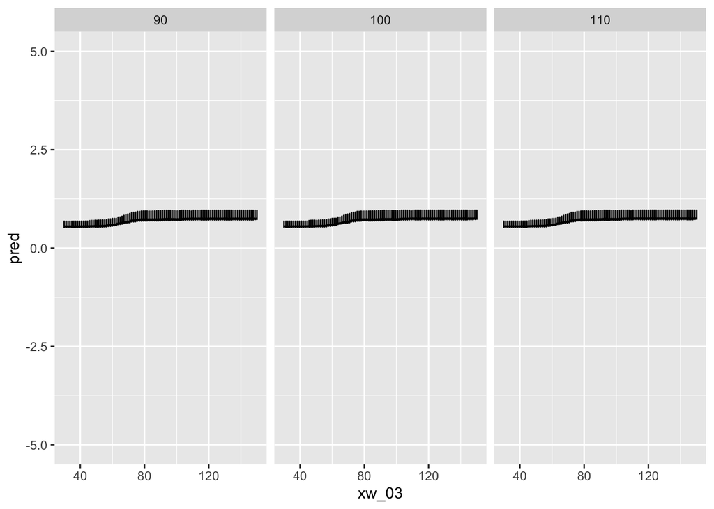

```r
pred<-predict(fit_rf_additive_tune,viz_grid)
viz_grid %>%
  bind_cols(pred) %>%
  ggplot(mapping=aes(x=xw_03)) +
  geom_line(mapping=aes(y=pred),size=0.5)+
  facet_grid(~xw_01)+
  coord_cartesian(ylim=c(-5,5))
```

I prefer to use the model of “c_fit_glmnet_2_tune”.

```r
viz_grid_c<- expand.grid(#xw_01 =seq(30,90,length.out=101) ,
                        xw_03=seq(90,120,length.out=101),
                        customer=c('Q'),
                        region=c('XX','YY','ZZ'),
                        xn_03=seq(-3,-1,length.out=4),
                        xb_01=c(0),xb_02=c(0),xb_03=c(0),xb_04=c(0),
                        xb_05=c(0),xb_06=c(0),xb_07=c(0),xb_08=c(0),
                        xn_01=c(0),xn_02=c(0),xn_04=c(0),
                        xn_05=c(0),xn_06=c(0),xn_07=c(0),xn_08=c(0),
                        xa_01=c(0),xa_02=c(0),xa_03=c(0),xa_04=c(0),
                        xa_05=c(0),xa_06=c(0),xa_07=c(0),xa_08=c(0),
                        xw_02=c(0),xw_01=c(0),
                        xs_01=c(0),xs_02=c(0),xs_03=c(0),xs_04=c(0),xs_05=c(0),xs_06=c(0),
                        KEEP.OUT.ATTRS = FALSE,
                        stringsAsFactors = FALSE) %>%
  as.data.frame() %>% tibble::as_tibble()
```

```r
pred<-predict(c_fit_glmnet_2_tune,viz_grid_c,type='prob')
```

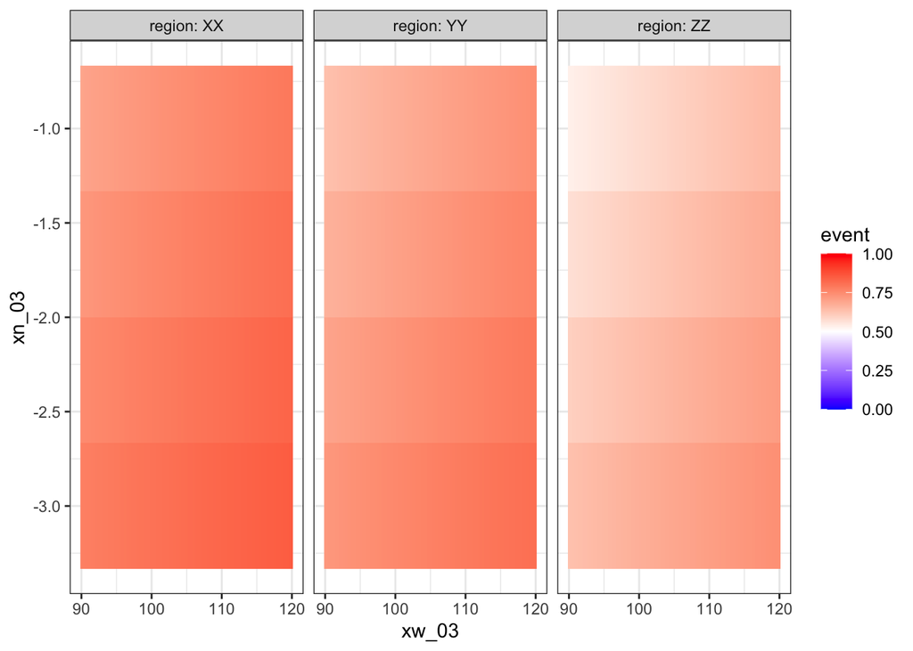

```r
viz_grid_c %>%
  bind_cols(pred) %>%
  ggplot(mapping = aes(x = xw_03, y = xn_03)) +
  geom_raster(mapping = aes(fill = event)) +
  facet_grid(~region, labeller = "label_both") +
  scale_fill_gradient2(limits = c(0, 1),
                       low = 'blue', high = 'red', mid = 'white',
                       midpoint = 0.5) +
  theme_bw()
```